# Lab 5: Data summary and visualization with R

## Datasets

### Built-in datasets in R

```r
data()  # all available datasets
data(package = "lattice")  # all data sets in a package
```

```r
data(barley, package = "lattice")  # read in the dataset without loading the package
help(barley, package = "lattice")  # get information about the dataset without loading the package
```

```r
# same as
library(lattice)  # load the package
data(barley)  # read in the dataset
help(barley)  # get information about the dataset
```

```r
head(barley)
```

```
##   yield   variety year            site
## 1 27.00 Manchuria 1931 University Farm
## 2 48.87 Manchuria 1931          Waseca
## 3 27.43 Manchuria 1931          Morris
## 4 39.93 Manchuria 1931       Crookston
## 5 32.97 Manchuria 1931    Grand Rapids
## 6 28.97 Manchuria 1931          Duluth
```

### External datasets

- http://exploringdata.net/datasets.htm
- http://lib.stat.cmu.edu/DASL/
- http://www.statsci.org/datasets.html

  and more…

A dataset from http://lib.stat.cmu.edu/DASL/ :

```
Story Names: Scents and Learning

Description: Data on the time subjects required to complete a pencil and paper maze when they were smelling a floral scent and when they were not.

Number of cases: 21

Variable Names:
ID:
Sex: M=male, F=female
Age: Age in years
Smoker: Y if subject smoked, N if did not
Opinion: "pos" if subject found the odor inherently positive, "indiff" if indifferent, "neg" if inherently negative
Order: 1 if did unscented trials first, 2 if did scented trials first
UTrial1: length of time required for first unscented trial
UTrial2: length of time required for second unscented trial
UTrial3: length of time required for third unscented trial
STrial1: length of time required for first scented trial
STrial2: length of time required for second scented trial
STrial3: length of time required for third scented trial
```

```r
sc = read.table("scents.txt", head = T)  # read in the data
names(sc)
```

```
##  [1] "ID"      "Sex"     "Smoker"  "Opinion" "Age"     "Order"   "UTrial1"
##  [8] "UTrial2" "UTrial3" "STrial1" "STrial2" "STrial3"
```

```r
head(sc)
```

```
##   ID Sex Smoker Opinion Age Order UTrial1 UTrial2 UTrial3 STrial1 STrial2
## 1  1   M      N     pos  23     1    38.4    27.7    25.7    53.1    30.6
## 2  2   F      Y     neg  43     2    46.2    57.2    41.9    54.7    43.3
## 3  3   M      N     pos  43     1    72.5    57.9    51.9    74.2    53.4
## 4  4   M      N     neg  32     2    38.0    38.0    32.2    49.6    37.4
## 5  5   M      N     neg  15     1    82.8    57.9    64.7    53.6    48.6
## 6  6   F      Y     pos  37     2    33.9    32.0    31.4    51.3    35.5
##   STrial3
## 1    30.2
## 2    56.7
## 3    42.4
## 4    34.4
## 5    44.8
## 6    42.9
```

```r
# Access a variable:
sc$Age
```

```
##  [1] 23 43 43 32 15 37 26 35 26 31 35 55 25 39 25 26 33 62 54 38 65
```

```r
# Access a variable by its name:
Age
```

```
## Error: object 'Age' not found
```

```r
attach(sc)  # to access the variable names
Age
```

```
##  [1] 23 43 43 32 15 37 26 35 26 31 35 55 25 39 25 26 33 62 54 38 65
```

```r
detach(sc)  # clean up
```

## Summary statistics and graphical displays

This simple command gives a (univariate) summary of each column:

```r
summary(sc)  # gives mean and five number summary for numeric type, and counts for charactor type
```

```
##        ID     Sex    Smoker   Opinion        Age           Order
##  Min.   : 1   F:10   N:13   indiff: 4   Min.   :15.0   Min.   :1.00
##  1st Qu.: 6   M:11   Y: 8   neg   : 7   1st Qu.:26.0   1st Qu.:1.00
##  Median :11                 pos   :10   Median :35.0   Median :1.00
##  Mean   :11                             Mean   :36.6   Mean   :1.48
##  3rd Qu.:16                             3rd Qu.:43.0   3rd Qu.:2.00
##  Max.   :21                             Max.   :65.0   Max.   :2.00
##     UTrial1        UTrial2        UTrial3        STrial1
##  Min.   :32.8   Min.   :26.8   Min.   :25.7   Min.   :28.3
##  1st Qu.:40.9   1st Qu.:38.0   1st Qu.:37.2   1st Qu.:49.6
##  Median :49.5   Median :46.8   Median :43.2   Median :53.6
##  Mean   :53.9   Mean   :48.9   Mean   :47.2   Mean   :55.5
##  3rd Qu.:60.1   3rd Qu.:57.9   3rd Qu.:58.0   3rd Qu.:67.3
##  Max.   :93.8   Max.   :91.9   Max.   :77.4   Max.   :77.5
##     STrial2         STrial3
##  Min.   : 25.1   Min.   :24.8
##  1st Qu.: 36.8   1st Qu.:34.4
##  Median : 44.0   Median :42.9
##  Mean   : 48.3   Mean   :43.3
##  3rd Qu.: 53.4   3rd Qu.:48.4
##  Max.   :126.6   Max.   :64.5
```

### Univariate data I - categorical

#### Factors

```r
# A character vector is automatically treated as a factor:
is.factor(sc$Sex)
```

```
## [1] TRUE
```

```r
sc$Order
```

```
##  [1] 1 2 1 2 1 2 1 2 1 2 1 2 1 2 1 2 1 2 1 2 1
```

```r
is.factor(sc$Order)  # 'Order' is coded as numeric but in fact a categorical variable!
```

```
## [1] FALSE
```

```r
sc$Order = factor(sc$Order)  # now treated as a categorical variable
sc$Order  # levels are printed; levels are numeric
```

```
##  [1] 1 2 1 2 1 2 1 2 1 2 1 2 1 2 1 2 1 2 1 2 1
## Levels: 1 2
```

#### Frequency tables

```r
table(sc$Order)
```

```
##
##  1  2
## 11 10
```

```r
# same as
summary(sc$Order)
```

```
##  1  2
## 11 10
```

#### bar plots

```r
barplot(sc$Smoker)  # using raw data?
```

```
## Error: 'height' must be a vector or a matrix
```

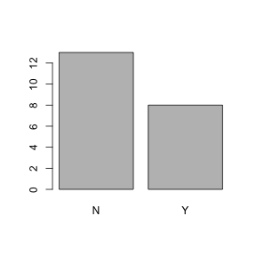

```r
barplot(table(sc$Smoker))  # using summarized data!
```

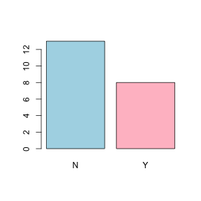

```r
barplot(table(sc$Smoker), col = c("light blue", "pink"))  # change color
```

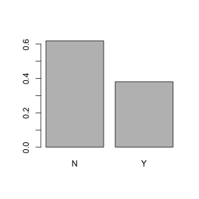

```r
barplot(table(sc$Smoker)/length(sc$Smoker))  # proportions
```

```r
table(sc$Smoker)/length(sc$Smoker)  # proportions
```

```
##
##     N     Y
## 0.619 0.381
```

#### Pie charts

```r
(tb <- table(sc$Opinion))  # make assignment as well as print the object
```

```
##
## indiff    neg    pos
##      4      7     10
```

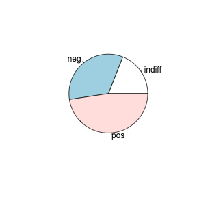

```r
pie(tb)
```

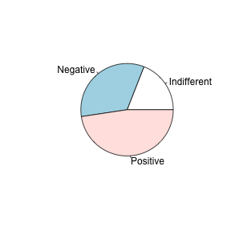

```r
names(tb) = c("Indifferent", "Negative", "Positive")  # new labels for levels
pie(tb)  # now with new labels
```

### Univariate data II - numerical

#### Five number summary

```r
fivenum(sc$Age)  # min, lower hinge, dedian, upper hinge, max
```

```
## [1] 15 26 35 43 65
```

```r
summary(sc$Age)  # five number summary and mean
```

```
##    Min. 1st Qu.  Median    Mean 3rd Qu.    Max.
##    15.0    26.0    35.0    36.6    43.0    65.0
```

#### Stem-and-leaf plots

```r
stem(sc$UTrial1)
```

```
##
##   The decimal point is 1 digit(s) to the right of the |
##
##   2 | 34588
##   4 | 1466800668
##   6 | 0355
##   8 | 34
```

```r
stem(sc$UTrial1, scale = 2)  # a longer plot
```

```
##
##   The decimal point is 1 digit(s) to the right of the |
##
##   3 | 34588
##   4 | 14668
##   5 | 00668
##   6 | 0
##   7 | 355
##   8 | 3
##   9 | 4
```

#### Histograms

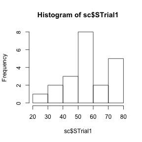

```r
hist(sc$STrial1)
```

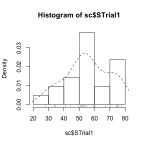

```r
hist(sc$STrial1, prob = T)  # proportions; area under the histogram equals 1
rug(sc$STrial1)  # add tick marks
lines(density(sc$STrial1), lty = 2)  # add a dotted density curve
```

#### Box plots

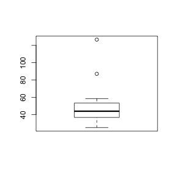

```r
boxplot(sc$STrial2)
```

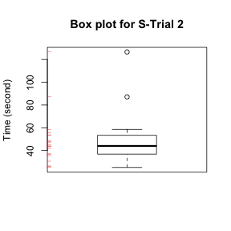

```r
boxplot(sc$STrial2, main = "Box plot for S-Trial 2", ylab = "Time (second)")  # Add main title and y-axis title
rug(sc$STrial2, side = 2, col = "red")  # add tick marks
```

### Bivariate data I - categorical vs. categorical

#### Contingency tables

```r
table(sc$Smoker, sc$Sex)
```

```
##
##     F M
##   N 4 9
##   Y 6 2
```

```r
table(Smoker = sc$Smoker, Sex = sc$Sex)  # prints names as given
```

```
##       Sex
## Smoker F M
##      N 4 9
##      Y 6 2
```

#### bar plots

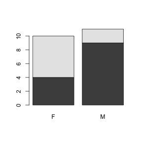

```r
barplot(table(sc$Smoker, sc$Sex))
```

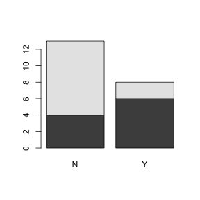

```r
barplot(table(sc$Sex, sc$Smoker))
```

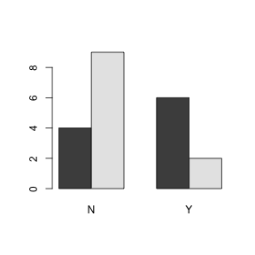

```r
barplot(table(sc$Sex, sc$Smoker), beside = T)  # besides; default is stacked
```

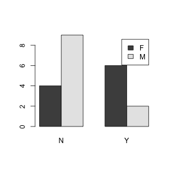

```r
barplot(table(sc$Sex, sc$Smoker), beside = T, legend.text = T)  # add a legend
```

### Bivariate data II - categorical vs. numerical

#### Box plots

```r
boxplot(sc$UTrial1 ~ sc$Sex)  # a side by side box plot
```

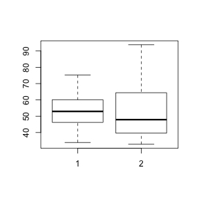

```r
# same as above except for x-axis labels
boxplot(sc$UTrial1[sc$Sex == "F"], sc$UTrial1[sc$Sex == "M"])
```

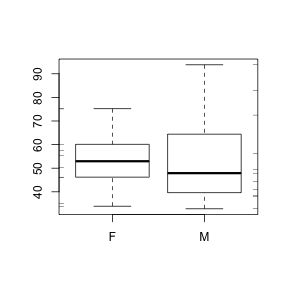

```r
# change axis labels
boxplot(sc$UTrial1[sc$Sex == "F"], sc$UTrial1[sc$Sex == "M"], xaxt = "n")  # no x-axis
axis(1, at = 1:2, labels = c("F", "M"))  # new x-axis
rug(sc$UTrial1[sc$Sex == "F"], side = 2)  # add a rug
rug(sc$UTrial1[sc$Sex == "M"], side = 4)  # add a rug
```

#### Stripcharts (dot plots)

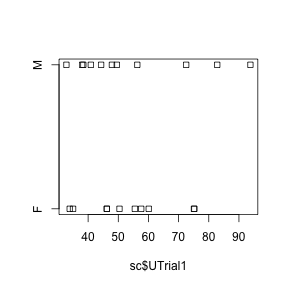

```r
stripchart(sc$UTrial1 ~ sc$Sex)
```

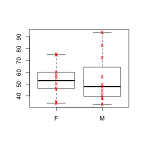

```r
# Add a stripchart to a box plot:
boxplot(sc$UTrial1 ~ sc$Sex)
stripchart(sc$UTrial1 ~ sc$Sex, vertical = T, col = "red", pch = "x", add = T)
```

### Bivariate data III - numerical vs. numerical

#### Correlation coefficients

Strengh of the 'linear' relationship between two numerical variables

```r
cor(sc$UTrial1, sc$STrial1)
```

```
## [1] 0.6317
```

```r
cor(sc[, 7:12])  # correlation matrix
```

```
##         UTrial1 UTrial2 UTrial3 STrial1 STrial2 STrial3
## UTrial1  1.0000  0.8410  0.8357  0.6317  0.3348  0.3962
## UTrial2  0.8410  1.0000  0.7678  0.5986  0.4371  0.5728
## UTrial3  0.8357  0.7678  1.0000  0.5879  0.3746  0.4433
## STrial1  0.6317  0.5986  0.5879  1.0000  0.5431  0.5167
## STrial2  0.3348  0.4371  0.3746  0.5431  1.0000  0.5600
## STrial3  0.3962  0.5728  0.4433  0.5167  0.5600  1.0000
```

#### Scatter Plots

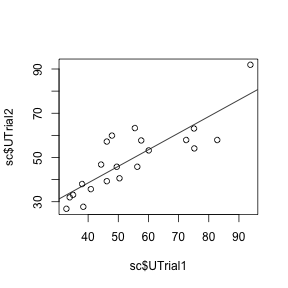

```r
plot(sc$UTrial1, sc$UTrial2)
abline(lm(sc$UTrial2 ~ sc$UTrial1))  # add the regression line of UTrial2 on UTrial1 (y on x)
```

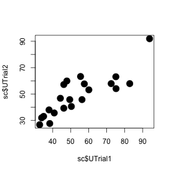

```r
plot(sc$UTrial1, sc$UTrial2, type = "n")  # no points or lines
points(sc$UTrial1, sc$UTrial2, pch = 19, cex = 2)  # plot points
```

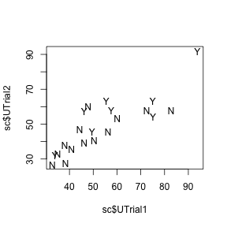

```r
plot(sc$UTrial1, sc$UTrial2, type = "n")  # no points or lines
text(sc$UTrial1, sc$UTrial2, labels = sc$Smoker)  # plot character strings
```

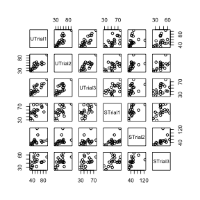

```r
# All pairwise scatter plots:
plot(sc[, 7:12])
```

```r
# 'plot' for numerical vs. categorical?
plot(sc$Sex, sc$UTrial1)
```

```r
# same as
boxplot(sc$UTrial1 ~ sc$Sex)
```

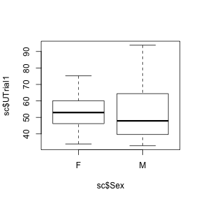

```r
# also same as this except for x, y axis labels
plot(sc$UTrial1 ~ sc$Sex)
```

## R Graphics

### High-level plotting functions

- 'plot' = scatter plot
- 'hist' = histogram
- 'boxplot' = box plot
- 'stripchart' = strip chart
- 'barplot' = bar plot
- 'stem' = stem-and-leaf plot
- 'curve' = curve corresponding to a function or an expression.

  and more …

```r
# Arguments of the 'plot' function:
help(plot)
```

[output not shown]

### Lower-level plotting functions

To add further elements to the main plot

```r
help(plot.default)
help(par)
```

- 'axis' adds an axis on the specified side.
- 'title' adds titles (main, sub) and axis lables.
- 'lines' draws single line that connect the points at the specified coordinates.
- 'abline' draws single straight line with the specified slope and intercepts.
- 'text' draws a sequence of strings at the specified coordinates.
- 'points' draws a sequence of points at the specified coordinates.
- 'legend' adds a legend.
- 'rug' adds tick marks on the specified side.

### Setting graphical parameters using 'par'

Permanant changes in graphical parameters for the current graphic device.

```r
help(par)
```

Combining multiple plots:

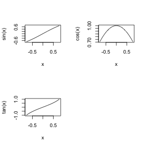

```r
par(mfrow = c(2, 2))  # a 2x2 matrix of plots filled in by row
x = seq(-pi/4, pi/4, 0.01)
plot(x, sin(x), type = "l")
plot(x, cos(x), type = "l")
plot(x, tan(x), type = "l")
```

Restoring original settings (from Quick-R http://www.statmethods.net/advgraphs/parameters.html):

```r
par()  # view current settings
opar = par()  # make a copy of current settings
par(col.lab = "red")  # red x and y labels
hist(mtcars$mpg)  # create a plot with these new settings
par(opar)  # restore original settings
```

## Exercise

- Read in the 'barley' dataset in the 'lattice' package.
- Attach the data.
- Obtain univariate summary statistics for each variable.
- Make a histogram for yield.
- Make a contingency table for variety and site.
- Using a side-by-side box plot, investigate the relationship between yield and variety. Repeat this for yield and site.
- Enter in the following data.

  x: 4 9 9 10 9 8 4 7 9 3

  y: 9 19 20 21 18 17 9 15 20 7
- Make a scatter plot of x and y.
- Add a straight line with slope = 2, y-intercept = 1 using one of the following.
  - abline(a = 1, b = 2)
  - s = seq(3, 10, .1); lines(s, 2*s + 1)
  - curve(2*x + 1, 3, 10, add = T)
- Do not leave RStudio until you learn how to save your work in the next lab session.